# Distributions and Sampling

## Intro: Uniform Distributions

A uniform distribution takes that “equal events have equal probability” concepts and extends it to **continuous** outcomes. The examples I gave before were **discrete**: there were a given number of possibilities (2, 6, or 12) and we gave each one an equal probability. But we want to pick *any number* between *a* and *b*, and there are infinitely many such numbers. So how do you formalize the idea that all outcomes should have the same probability? The solution is to mandate that the *area under the distribution* must equal 1.

In the context of uniform distributions, this may seem like an unnecessary amount of math. If I randomly pick a value between 3 and 5, of course there’s a 50% chance that it will be less than 4! That’s what that means! But once you move to more involved distribution, having an understanding of how that math works will be extremely helpful.

For example: Let’s say instead that you wanted to pick an adult at random from the global population, and wanted to know the probability of that person being over 6 feet (72 inches) tall. In that case, you would look at a *normal distribution* reflective of human height worldwide:

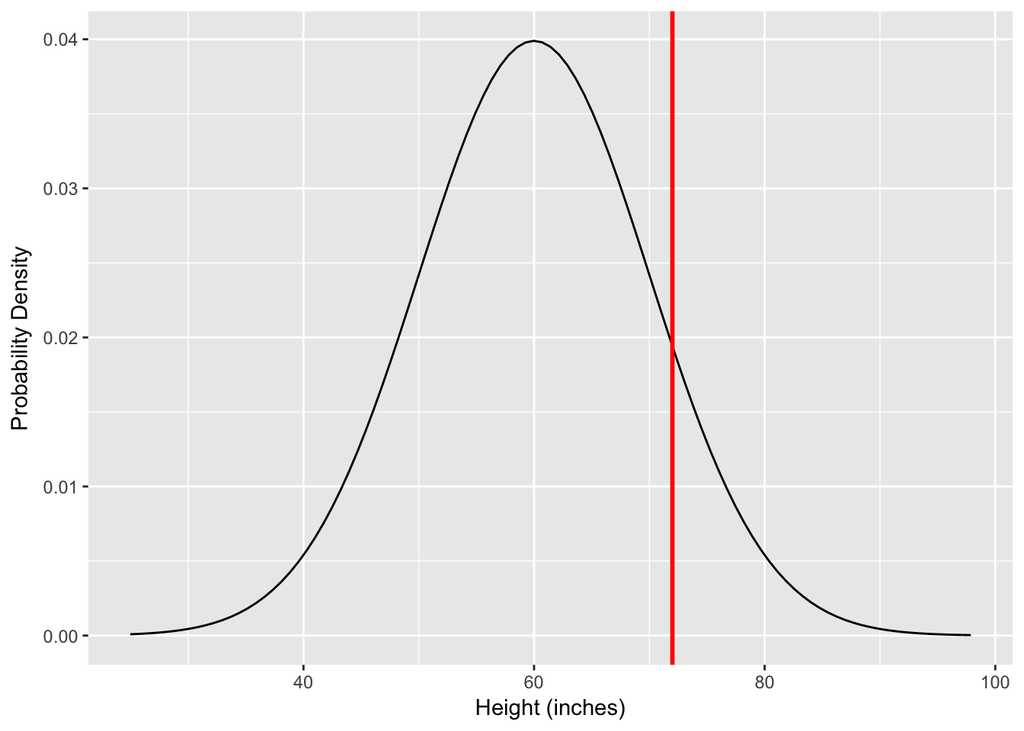

Just like with uniform distributions, the *area under this curve* must equal 1. So if you wanted to know the probability that someone was over 6 feet, you’d use software like R to calculate the area under the curve between the red line (at 72 inches) and the edge of the plot. I used the function `pnorm` to discover that the area under the curve from 72 onwards is 0.115. So, according to this distribution, there’s an 11.5% chance that a random adult you pick off the street will be over 6 feet tall.

(Note: I just made up the data for this plot, true distributions of human height look very different.)

Different distributions are defined in different ways and serve different purposes. As we’ve seen, uniform distributions are used when we’re studying *continuous events* that happen with *equal probability*. Below we describe two of the most common distributions: Normal and Binomal.

## Normal Distributions: Means and Standard Errors

You’ve probably heard the term “normal distribution” (also called a “Gaussian distribution” or, colloquially, “bell curve”), before. Normal distributions define most aspects of daily life. Just about any *continuous random variable*, like height or test score results, will *converge* to a normal distribution. What that means is that, as you take more and more samples from the population, and make a histogram, that plot will start to look more and more like a normal distribution:

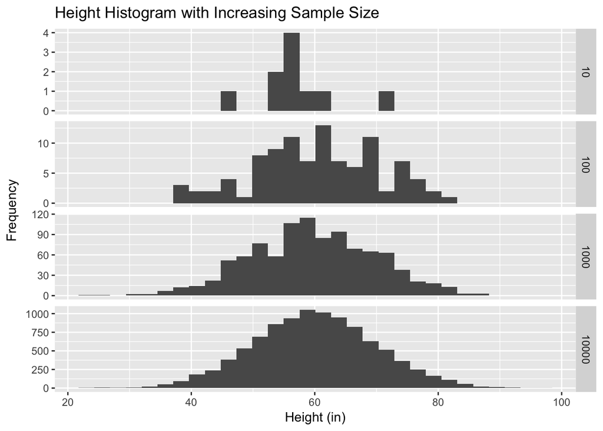

It also turns out that normal distributions have a lot of nice properties that make statistics easy. Many statistical methods rely on the assumption that you’re pulling data from a *normally distributed* variable.

That’s all well and good, but what *is* a normal distribution? How do you define it?

A line is completely defined by two parameters: $m$, the slope (how steep the line is), and $b$, the intercept (where the line crosses the y-axis). Change either of those two parameters, and you make a different line.

Normal distributions are also defined by two parameters: the **mean** of the distribution, $\mu$ (“mu”, pronounced “mew”), and the **variance**, $\sigma^2$ (“sigma squared”)[^1].The formula for a normal distribution is a little more complicated than the one for a line, but the basic idea is the same–change either of those two variables, and you get a different distribution.

$$P(x | \mu,\sigma^2) = \frac{1}{{\sqrt{2\sigma^2\pi}}}e^{-\frac{(x-\mu)^2}{2\sigma^2}}$$

The left part of that equation is read as, “The *probability* of $x$ *given* $\mu$ and $\sigma^2$” is…

## Binomial Distributions: Number of Trials and Probabilities of “Success”

Let’s say you’re flipping a coin, and you want to know your probability of getting four heads if you flip six times. It should be clear that you can’t go to a normal distribution for this problem– the outcome of a coin flip is *random*, but it’s not *continuous*. It can only take one of two values– heads or tails. For this type of *binary* outcome, we use a **binomial** distribution.

Binomial distributions are also defined by two paramters: the *number of trials*, $n$ (that is, the number of times you flip the coin), and the *probability of success*, $p$ (for a fair coin, the probability of getting “heads” is 0.5). The probability of getting $k$ successes in a binomial distribution is

$$P(X=k | n,p) = {{n}\choose{k}}p^k(1-p)^{(n-k)}$$
Where ${n}\choose{k}$ means “n choose k”. ${n}\choose{k}$ is a count of how many different ways you can pull a subset of $k$ elements from a set of $n$ elements. Specifically it means:

$${{n}\choose{k}} = \frac{n!}{k!(n-k)!}$$
Where $!$ means “factorial”– $5!$ means $5*4*3*2*1=120$.

## What is a Sample?

Now let’s say that I measure the height of an individual pulled randomly from the global adult population, like the woman standing in line at the cafe where I’m writing this. She looks to be around 5 feet (60 inches) tall. Next, I’ll pull another measurement from this population– the height of my father, who is about 6’2" (74 inches). How do these two measurements relate to the normal distribution in the plot?

These two height measurements are *samples* from the global height distribution. A **sample** is a piece of data that we actually see. We can never fully “capture” an entire distribution because distributions are infinite and unknown– all we can do is take observations from a distribution and let those observations help us understand the shape of that distribution.

### What Assumptions Do We Make When We Sample?

When sampling from a population, our most fundamental assumption is that *the data we’re collecting is an unbiased reflection of the distribution it’s drawn from*. This assumption can be mistaken for a number of reasons we’ll get to in the next lecture.

```
## [1] "For n of 10 data has mean 56.9325746367689 and variance 49.9677423547699"
## [1] "For n of 100 data has mean 60.462049236914 and variance 100.387302061785"
## [1] "For n of 1000 data has mean 59.715458642628 and variance 102.857659633632"
## [1] "For n of 10000 data has mean 59.9973470397236 and variance 98.8892786659453"
```

Notice that the higher my value of $n$, the closer I get to the true parameters of the distribution I was pulling from (but always with some random error!)

Now, let’s get into more detail about what can go wrong with sampling, especially when you’re sampling *people*…

[^1]: The square root of the variance, $\sigma$, is called the **standard deviation**. It will come up later.